# Data modeling

Quan Gan, Yuxuan chen

11/16/2021

# Data Modeling

```r
# load libraries
library(tidyverse)
library(knitr)
library(effects)
library(ggthemes)
```

```r
# load data in
LCA_application <- read_csv("Data/LCA_cleaned.csv")
```

```r
# set seed
set.seed(1)

# sample records from dataset
certified <- LCA_application %>%
  filter(case_status == "certified") %>%
  sample_n(10000)

denied <- LCA_application %>%
  filter(case_status == "denied") %>%
  sample_n(10000)


LCA_sample <- rbind(certified, denied)

# The wage_rate_from_year is the minimum paid wage rate and wage_rate_to_year is the
# maximum paid wage rate. So, we need to calculate the mean wage rate.
LCA_sample <- LCA_sample %>%
  mutate(mean_wage_rate_year = ifelse(wage_rate_to_year == 0,
                                      wage_rate_from_year,
                                      (wage_rate_from_year + wage_rate_to_year)/2))

LCA_sample <- LCA_sample %>%
  mutate(difference_prevailing_wage = mean_wage_rate_year - prevailing_wage_year)
```

## Model 1

> Question: What is the relationship of year and wage_rate_from_year aroess case status?

```r
# create model
model_wage_rate_from_year <- lm( wage_rate_from_year ~ year, data = LCA_sample)

summary(model_wage_rate_from_year)
```

```
##
## Call:
## lm(formula = wage_rate_from_year ~ year, data = LCA_sample)
##
## Residuals:
##       Min        1Q    Median        3Q       Max
##  -1617139  -1069228   -584799    -85045 431007781
##
## Coefficients:
##               Estimate Std. Error t value Pr(>|t|)
## (Intercept) -945864446  110167581  -8.586   <2e-16 ***
## year            469058      54598   8.591   <2e-16 ***
## ---
## Signif. codes:  0 '***' 0.001 '**' 0.01 '*' 0.05 '.' 0.1 ' ' 1
##
## Residual standard error: 10580000 on 19998 degrees of freedom
## Multiple R-squared:  0.003677,   Adjusted R-squared:  0.003627
## F-statistic: 73.81 on 1 and 19998 DF,  p-value: < 2.2e-16
```

Visualizing the model predictor

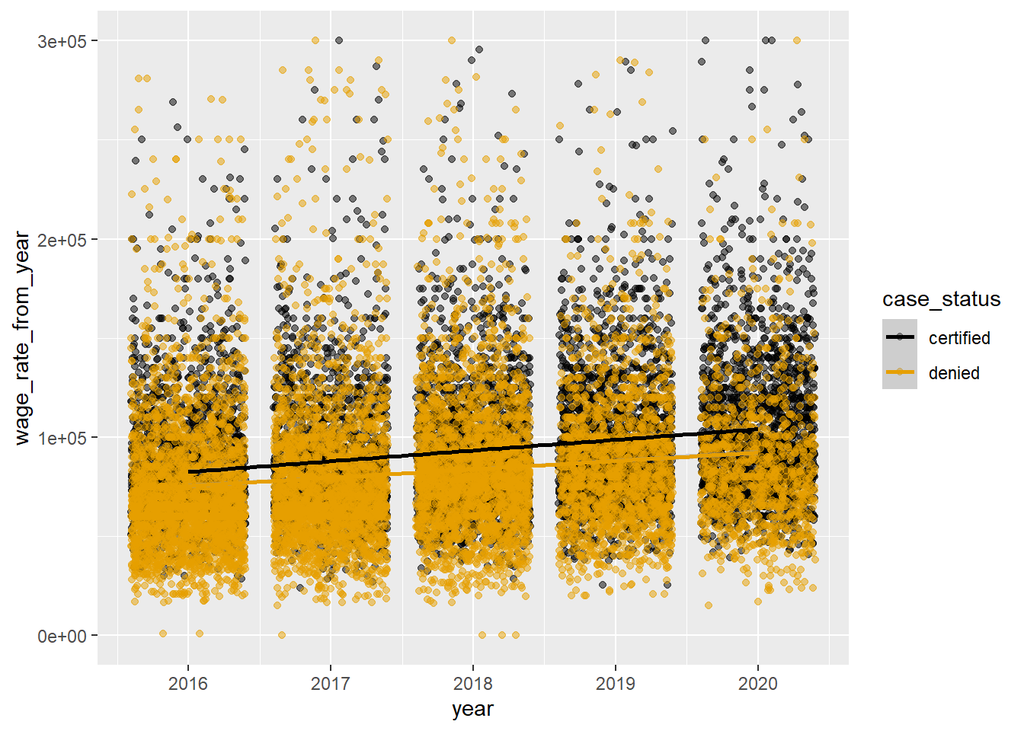

```r
LCA_sample %>%
  ggplot(aes(x = year,
             y = wage_rate_from_year,
             color = case_status)) +
  geom_jitter(alpha = 0.5) +
  geom_smooth(formula = y ~ x, method = "lm") +
  ylim(0, 300000) +
  scale_color_colorblind()
```

## Model 2

> Question: What is the relationship between wage_rate_from_year of denied case_status and state?

```r
denied_case <- LCA_application %>%
  filter(case_status == "denied")

model_prevailing_wage_state <- lm(wage_rate_from_year ~ worksite_state, data = denied_case)

summary(model_prevailing_wage_state)
```

```
##
## Call:
## lm(formula = wage_rate_from_year ~ worksite_state, data = denied_case)
##
## Residuals:
##       Min        1Q    Median        3Q       Max
##  -5511327  -1135114   -863098   -572040 597658513
##
## Coefficients:
##                                              Estimate Std. Error t value
## (Intercept)                                   2590996    1141926   2.269
## worksite_statealaska                         -2501285    3081086  -0.812
## worksite_statearizona                        -1970286    1340640  -1.470
## worksite_statearkansas                       -1243279    1707636  -0.728
## worksite_statecalifornia                     -1651080    1155805  -1.429
## worksite_statecolorado                       -1894242    1374384  -1.378
## worksite_stateconnecticut                     -935434    1387900  -0.674
## worksite_statedelaware                        2950491    1653982   1.784
## worksite_statedistrict of columbia            -563116    1424773  -0.395
## worksite_statefederated states of micronesia -2502646   10181732  -0.246
## worksite_stateflorida                        -2184751    1203064  -1.816
## worksite_stategeorgia                        -1451171    1226826  -1.183
## worksite_stateguam                           -2527355    2586804  -0.977
## worksite_statehawaii                         -2503538    1941801  -1.289
## worksite_stateidaho                          -2501265    2184937  -1.145
## worksite_stateillinois                       -1622351    1205358  -1.346
## worksite_stateindiana                          124140    1397828   0.089
## worksite_stateiowa                           -2464499    1622774  -1.519
## worksite_statekansas                         -2505425    1581528  -1.584
## worksite_statekentucky                       -1191694    1760639  -0.677
## worksite_statelouisiana                      -2495061    1597602  -1.562
## worksite_statemaine                          -2477149    2644025  -0.937
## worksite_statemaryland                       -1121368    1291619  -0.868
## worksite_statemassachusetts                  -1699946    1206131  -1.409
## worksite_statemichigan                       -1148267    1231499  -0.932
## worksite_stateminnesota                      -2492161    1321428  -1.886
## worksite_statemississippi                    -2500389    1982096  -1.261
## worksite_statemissouri                       -1372202    1408600  -0.974
## worksite_statemontana                        -2511439    2359904  -1.064
## worksite_statenebraska                       -2489634    1783880  -1.396
```

[output cut: 75 more lines]

```
## worksite_stateutah                             0.1851
## worksite_statevermont                          0.3652
## worksite_statevirgin islands                   0.4642
## worksite_statevirginia                         0.3206
## worksite_statewashington                       0.1099
## worksite_statewest virginia                    0.2507
## worksite_statewisconsin                        0.6757
## worksite_statewyoming                          0.5333
## ---
## Signif. codes:  0 '***' 0.001 '**' 0.01 '*' 0.05 '.' 0.1 ' ' 1
##
## Residual standard error: 14310000 on 31736 degrees of freedom
##   (31 observations deleted due to missingness)
## Multiple R-squared:  0.001631,   Adjusted R-squared:  -9.94e-05
## F-statistic: 0.9425 on 55 and 31736 DF,  p-value: 0.5961
```

The result (p > 0.05) shows we could not reject null hypothesis, so the denied case wage_rate_from_year have no relationship with state.

## Model 3

> Effect of worksite_state, prevailing_wage_year on wage_rate_from_year of data science related occupations

```r
# filter original data set and select data science related jobs.
ds_occupation <- c("machine learning", "data scientist", "data engineer", "data analyst")

LCA_application <- LCA_application %>%
  mutate(occupation = case_when(grepl("machine learning", job_title, fixed = TRUE) ~ "machine learning",
                                grepl("data scientist", job_title, fixed = TRUE) ~ "data scientist",
                                grepl("data engineer", job_title, fixed = TRUE) ~ "data engineer",
                                grepl("data analyst", job_title, fixed = TRUE) ~ "data analyst",
                                TRUE ~ job_title))

LCA_application %>%
  filter(occupation %in% ds_occupation) %>%
  count(occupation) %>%
  kable()
```

| occupation | n |
| --- | --- |
| data analyst | 17861 |
| data engineer | 12113 |
| data scientist | 16835 |
| machine learning | 2886 |

```r
LCA_ds <- LCA_application %>%
  filter(occupation %in% ds_occupation)

model_ds <- lm(wage_rate_from_year ~ prevailing_wage_year + worksite_state + occupation, data = LCA_ds)

summary(model_ds)
```

```
##
## Call:
## lm(formula = wage_rate_from_year ~ prevailing_wage_year + worksite_state +
##     occupation, data = LCA_ds)
##
## Residuals:
##       Min        1Q    Median        3Q       Max
## -27512607    -81197    -36454      8654 294289283
##
## Coefficients:
##                                      Estimate Std. Error t value Pr(>|t|)
## (Intercept)                         2.767e+04  3.305e+05   0.084 0.933288
## prevailing_wage_year                9.308e-02  7.689e-03  12.105  < 2e-16 ***
## worksite_statearizona              -1.997e+03  3.570e+05  -0.006 0.995537
## worksite_statearkansas             -2.195e+03  3.702e+05  -0.006 0.995269
## worksite_statecalifornia            5.127e+04  3.313e+05   0.155 0.877003
## worksite_statecolorado             -1.089e+03  3.716e+05  -0.003 0.997662
## worksite_stateconnecticut           1.879e+03  3.537e+05   0.005 0.995760
## worksite_statedelaware              7.509e+03  4.055e+05   0.019 0.985228
## worksite_statedistrict of columbia  7.885e+03  3.798e+05   0.021 0.983439
## worksite_stateflorida               2.350e+05  3.457e+05   0.680 0.496587
## worksite_stategeorgia               9.414e+03  3.377e+05   0.028 0.977761
## worksite_stateguam                  4.813e+04  3.062e+06   0.016 0.987457
## worksite_statehawaii                2.228e+04  7.565e+05   0.029 0.976504
## worksite_stateidaho                -1.373e+04  5.016e+05  -0.027 0.978166
## worksite_stateillinois              8.691e+04  3.357e+05   0.259 0.795686
## worksite_stateindiana              -1.242e+04  3.767e+05  -0.033 0.973701
## worksite_stateiowa                  5.970e+03  3.944e+05   0.015 0.987924
## worksite_statekansas               -5.136e+03  4.253e+05  -0.012 0.990364
## worksite_statekentucky             -1.661e+04  4.774e+05  -0.035 0.972239
## worksite_statelouisiana             8.986e+03  5.158e+05   0.017 0.986099
## worksite_statemaine                 1.329e+04  7.564e+05   0.018 0.985979
## worksite_statemaryland              2.113e+04  3.472e+05   0.061 0.951459
## worksite_statemassachusetts         1.029e+05  3.360e+05   0.306 0.759421
## worksite_statemichigan             -7.258e+03  3.449e+05  -0.021 0.983208
## worksite_stateminnesota             1.674e+03  3.497e+05   0.005 0.996180
## worksite_statemississippi          -1.182e+03  1.018e+06  -0.001 0.999073
## worksite_statemissouri             -9.748e+03  3.545e+05  -0.027 0.978066
## worksite_statemontana               3.060e+04  1.401e+06   0.022 0.982572
## worksite_statenebraska             -1.384e+03  4.118e+05  -0.003 0.997317
```

[output cut: 18 more lines]

```
## worksite_statevermont              -2.673e+04  1.286e+06  -0.021 0.983413
## worksite_statevirginia              1.258e+05  3.369e+05   0.373 0.708800
## worksite_statewashington            3.007e+03  3.343e+05   0.009 0.992825
## worksite_statewest virginia         1.879e+04  9.754e+05   0.019 0.984630
## worksite_statewisconsin             1.909e+03  3.744e+05   0.005 0.995932
## worksite_statewyoming               4.646e+03  1.286e+06   0.004 0.997117
## occupationdata engineer             6.362e+04  3.691e+04   1.723 0.084814 .
## occupationdata scientist            1.175e+05  3.395e+04   3.461 0.000539 ***
## occupationmachine learning          4.435e+04  6.274e+04   0.707 0.479676
## ---
## Signif. codes:  0 '***' 0.001 '**' 0.01 '*' 0.05 '.' 0.1 ' ' 1
##
## Residual standard error: 3044000 on 49639 degrees of freedom
## Multiple R-squared:  0.003413,   Adjusted R-squared:  0.002309
## F-statistic: 3.091 on 55 and 49639 DF,  p-value: 1.212e-13
```

The result shows only prevailing_wage_year and date scientist occupation has effects on wage_rate_from_year of data science related occupations

```r
model_ds <- lm(wage_rate_from_year ~ prevailing_wage_year + occupation, data = LCA_ds)

summary(model_ds)
```

```
##
## Call:
## lm(formula = wage_rate_from_year ~ prevailing_wage_year + occupation,
##     data = LCA_ds)
##
## Residuals:
##       Min        1Q    Median        3Q       Max
## -27500520    -75443    -31069     -9322 294291708
##
## Coefficients:
##                             Estimate Std. Error t value Pr(>|t|)
## (Intercept)                8.135e+04  2.277e+04   3.572 0.000354 ***
## prevailing_wage_year       9.305e-02  7.685e-03  12.108  < 2e-16 ***
## occupationdata engineer    5.674e+04  3.581e+04   1.584 0.113107
## occupationdata scientist   1.127e+05  3.268e+04   3.447 0.000568 ***
## occupationmachine learning 4.259e+04  6.104e+04   0.698 0.485301
## ---
## Signif. codes:  0 '***' 0.001 '**' 0.01 '*' 0.05 '.' 0.1 ' ' 1
##
## Residual standard error: 3042000 on 49690 degrees of freedom
## Multiple R-squared:  0.003192,   Adjusted R-squared:  0.003111
## F-statistic: 39.77 on 4 and 49690 DF,  p-value: < 2.2e-16
```

The output shows there is a positive relationship between prevailing_wage_year and wage_rate_from_year of data science related occupations. Data scientist occupation also has a positive relationship.

Let’s visualize.

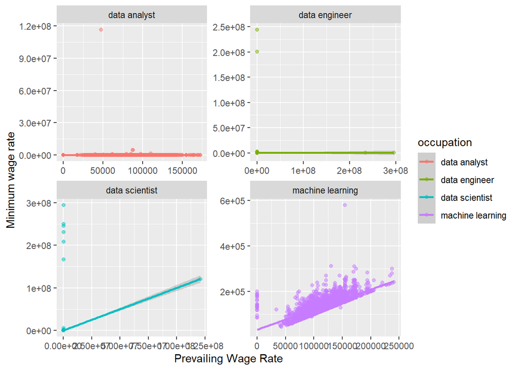

```r
LCA_ds %>%
  ggplot(aes(x = prevailing_wage_year,
             y = wage_rate_from_year,
             color = occupation)) +
  geom_jitter(alpha = .5) +
  facet_wrap(~occupation, scales = "free") +
  geom_smooth(method = "lm") +
  labs(x = "Prevailing Wage Rate",
       y = "Minimum wage rate")
```

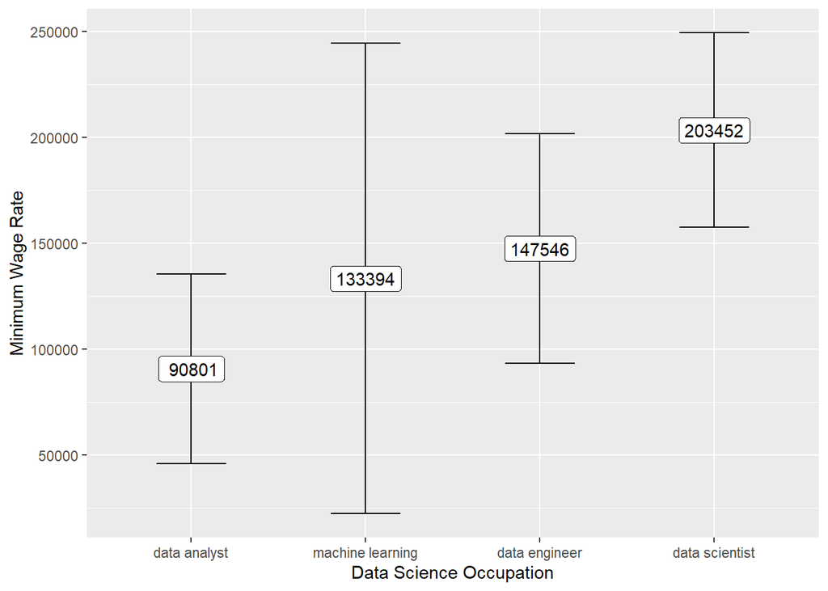

```r
effect("occupation", model_ds) %>%
  data.frame() %>%
  ggplot(aes(x = reorder(occupation, fit),
             y = fit,
             ymin = lower,
             ymax = upper,
             label = format(fit, digits = 2))) +
  geom_errorbar(width = .4) +
  geom_label() +
  labs(x = "Data Science Occupation",
       y = "Minimum Wage Rate")
```